# Title

# 3 Modeling

## 3.1 Predicting Anxiety from COVID Cases Using a Panel Model

We are searching for a way for school administrators to anticipate increased anxiety among their students. In 2020 and today, anecdotally, COVID is a significant source of anxiety. We used a panel model to find the predictiveness of covid cases on anxiety in 18-29 year olds.

Panel models are used for regression when the response and predictor variables are longitudinal. In this case, we treat US states as entities and have longitudinal values for both anxiety and new COVID cases.

For states $s=1,\dots, 50$ and time periods $t=1,\dots,T$, we use the model

$$\mbox{anx}_{s,t} = \alpha_s + \beta_1 \mbox{anx}_{s,t-1} + \beta_2 \mbox{COVID}_{s,t} + \varepsilon_{s,t}$$

This model allows for state-specific intercepts ($\alpha_s$), autocorrelation in anxiety within a state ($\beta_1$), and an effect of COVID cases on anxiety ($\beta_1$).

Alternatively, we can have a random effect for the state-specific intercepts, \begin{align*} \mbox{anx}_{s,t} &= \alpha + a_s + \beta_1 \mbox{anx}_{s,t-1} + \beta_2 \mbox{COVID}_{s,t} + \varepsilon_{s,t} \\ a_s &\sim N(0, \sigma^2_a) \end{align*}

The `plm` package in `R` allows us to fit both of these models and perform a hypothesis test to determine which fits our data better.

Because COVID cases can vary largely by state due to the size of the state, we were careful in how we constructed the $\mbox{COVID}_{s,t}$ covariate. We used the log ratio of new cases in sequential weeks as the COVID covariate:
$$\mbox{COVID}_{s,t} = \log\left(\frac{\text{New cases in state $s$ and week $t$}}{\text{New cases in state $s$ and week $t-1$}}\right).$$

This value is appealing for three reasons. First, it places all states on the same scale by only considering the ratio of subsequent weeks. Second, by using a ratio of new covid cases it handles the exponential growth nature of the pandemic. And third, it works well with an autoregressive model. A positive value means the pandemic is currently accelerating in a state, possibly resulting in increasing anxiety relative to week $t-1$. Similarly, a negative value means the pandemic is slowing down, possibly resulting in decreasing anxiety relative to week $t-1$.

### 3.1.1 Results

First, we have the output from the fixed effects model:

```
## Oneway (individual) effect Within Model
##
## Call:
## plm(formula = anx ~ LogCasesRatio + lag(anx), data = paneldata,
##     model = "within", index = c("State", "Date"))
##
## Unbalanced Panel: n = 50, T = 44-46, N = 2298
##
## Residuals:
##      Min.   1st Qu.    Median   3rd Qu.      Max.
## -0.929705 -0.107738 -0.026498  0.082389  2.783689
##
## Coefficients:
##               Estimate Std. Error t-value  Pr(>|t|)
## LogCasesRatio 0.040212   0.015592   2.579  0.009971 **
## lag(anx)      0.696476   0.015199  45.824 < 2.2e-16 ***
## ---
## Signif. codes:  0 '***' 0.001 '**' 0.01 '*' 0.05 '.' 0.1 ' ' 1
##
## Total Sum of Squares:    192.43
## Residual Sum of Squares: 99.396
## R-Squared:      0.48346
## Adj. R-Squared: 0.47173
## F-statistic: 1051.1 on 2 and 2246 DF, p-value: < 2.22e-16
```

We can see that both the lagged anxiety variable and LogCasesRatio are significant predictors. The value of the coefficient with $\mbox{COVID}_{s,t}$ shows that if new cases were to double from one week to the next, we expect our response anxiety odds to increase by 0.0279.

The `plm` package also allows us to run a Hausman hypothesis test to see whether a fixed effects or random effects model is a better fit for our data.

```
##
##  Hausman Test
##
## data:  anx ~ LogCasesRatio + lag(anx)
## chisq = 71.979, df = 2, p-value = 2.344e-16
## alternative hypothesis: one model is inconsistent
```

The small p-value indicates that the null hypothesis of a random effects model should be rejected, and so our results from the fixed effects model are a better fit.

## 3.2 Associating Google Trends Data with Anxiety Surveys

The search engine Google makes its search data available through Google Trends at https://trends.google.com/trends/. Using the package `gtrendsr`, relative search popularity over time of a specified keyword can be obtained for a variety of regions. Search popularity of the keywords "lockdown" and "covid" was gathered for the study period at US and state levels. Figure 3.1 shows the search popularity (0-100) of the word "covid" in the US from April 2020 to March 2021.

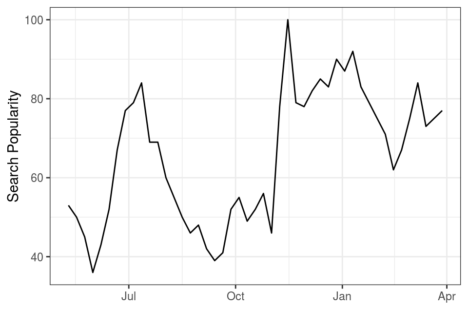

Figure 3.1: US Google Trends search popularity of "covid" over time.

Once again, a generally increasing pattern is noted, with a spike in November which may correspond with the 2020 elections. To compare search trends with anxiety data, we will instead find correlation with the first order differences of each data set. This will prevent spurious correlation of unit-root processes. The correlation was not very significant, even though the the trends do match by eye.

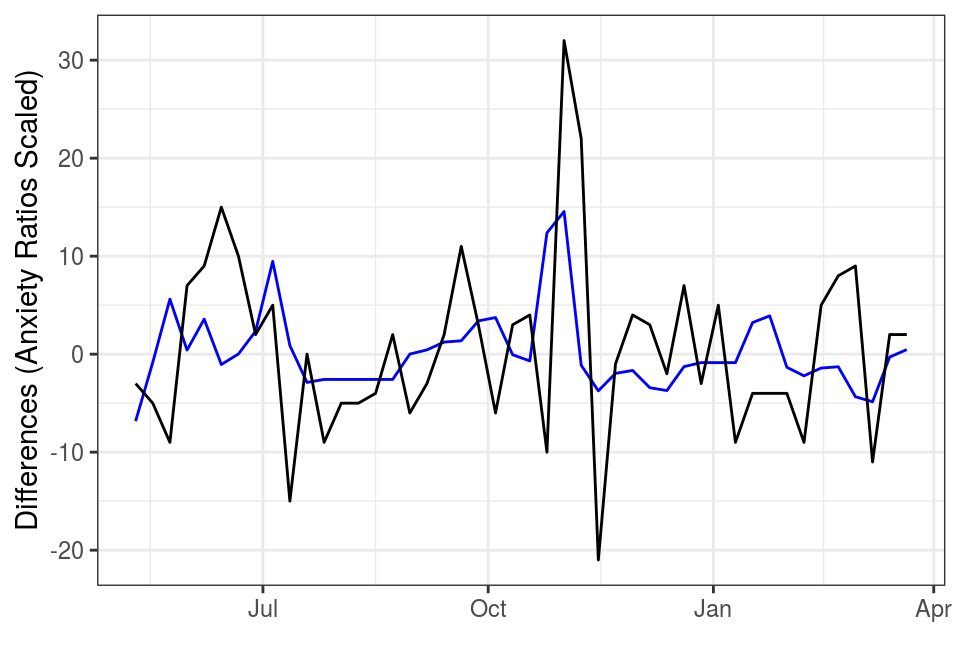

```
##
##  Pearson's product-moment correlation
##
## data:  anx_diffs$USdiffs and covidint_diffs$hitdiffs
## t = 1.8689, df = 44, p-value = 0.0683
## alternative hypothesis: true correlation is not equal to 0
## 95 percent confidence interval:
##  -0.02074294  0.52050889
## sample estimates:
##       cor
## 0.2711881
```

We further examined the search trends data across the 50 states. Correlations calculated between the first order differences in google trends and anxiety data are as follows:

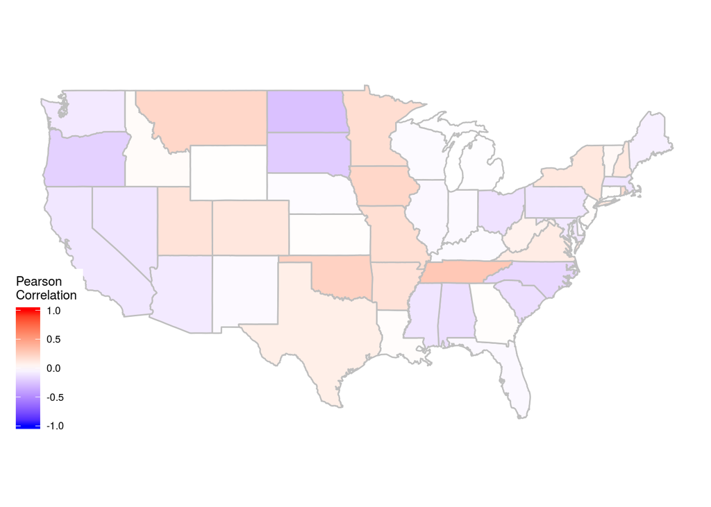

Figure 3.2: Using the keyword "covid".

As it was seen in the given map, there may be some spatial-temporal trends between the difference in anxiety ratio and differences in Google Search trends for Covid. For the sake of this project, the joint significance of correlations of Colorado (where the team is based) and of California was tested using a permutation test. Each statistic $T$ was calculated as

$$T=corr^2_{\text{California}}+corr^2_{\text{Colorado}}$$

The sampling distribution was derived using permutation sampling, wherein each iteration of each state's differences in anxiety ratio is assigned to a randomized state's differences in google trends. A sampling distribution was then obtained as $T_{1},\ldots, T_{1000}$.

We obtained $p=0.12$, thus the hypothesis of no significance cannot be rejected. Notice that taking into account the nature of data (noisy, interpolation), etc. One can argue that with $p-value$ around significance $0.1$ there may be potential for more research in this area.

# 4 Discussion

The anxiety changes in 18–29-year-olds is important for universities, as this age group makes up a large majority of college students. However, due to the lack of university public data on student anxiety levels, the finest level of analysis can be done only at the state level.

It is shown that the anxiety ratio of 18–29 year-olds in the United States went through significant perturbations and tended to increase. Such changes might negatively affect the performance and achievements of students.

The panel data analysis shows that there are possible links between changes in covid numbers and anxiety ratios. Although the direct causal link between variables might be not found, some intermediate variables, like stress about the current situation or the uncertainty about the future, possibly could help to explain such a link.

Additionally, the analysis between changes in google searches and changes in anxiety did not produce a significant relationship but showed to have potential. The "eye test" for some clusters of states suggests that some universities can use Google search data to get a general overview of what might be going on in the state and infer about their students.

The methodology described in this report can be easily expanded and should be utilized by universities. A possible extension would be to use a network analysis to find a relationship between COVID and anxiety for neighboring states. This relationship could allow universities to anticipate increases in anxiety earlier. Universities could also collect their own data about student anxiety to establish a more concrete relationship between the statewide anxiety of 18–29-year-olds and the anxiety of their students. This analysis could also be applied to more mental health outcomes such as depression.

R code for data collection, cleaning, interpolation where necessary, and analysis are available in the supplemental GitHub repository.

# 5 Bibliography

1. Brey, Cristobal de, Thomas D. Snyder, Anlan Zhang, and Sally A. Dillow. “Digest of Education Statistics, 2019.” NCES, February 25, 2021. https://nces.ed.gov/ipeds/Search?query=Age&query2=Age&resultType=all&page=1&sortBy=date_desc&collectionYears=2019-20&collectionYears=2018-19&overlayDigestTableId=201035.
2. Centers for Disease Control and Prevention, COVID-19 Response. COVID-19 Case Surveillance Public Data Access, Summary, and Limitations https://data.cdc.gov/Case-Surveillance/United-States-COVID-19-Cases-and-Deaths-by-State-o/9mfq-cb36
3. Croissant Y, Millo G (2008). “Panel Data Econometrics in R: The plm Package.” Journal of Statistical Software, 27(2), 1–43. doi: 10.18637/jss.v027.i02.
4. Fields JF, Hunter-Childs J, Tersine A, Sisson J, Parker E, Velkoff V, Logan C, and Shin H. Design and Operation of the 2020 Household Pulse Survey, 2020. U.S. Census Bureau https://www.census.gov/programs-surveys/household-pulse-survey/data.html
5. Ibrahim, Ahmed K., Shona J. Kelly, Clive E. Adams, and Cris Glazebrook. “A Systematic Review of Studies of Depression Prevalence in University Students.” Journal of Psychiatric Research 47, no. 3 (March 1, 2013): 391–400. https://doi.org/10.1016/j.jpsychires.2012.11.015.
6. Ku, H.H. “Notes on the Use of Propagation of Error Formulas.” Journal of Research of the National Bureau of Standards: Engineering and Instrumentation 70C, no. 4 (1966): 263–73.
7. Lijster, Jasmijn M. de, Bram Dierckx, Elisabeth M.W.J. Utens, Frank C. Verhulst, Carola Zieldorff, Gwen C. Dieleman, and Jeroen S. Legerstee. “The Age of Onset of Anxiety Disorders.” Canadian Journal of Psychiatry. Revue Canadienne de Psychiatrie 62, no. 4 (April 2017): 237–46. https://doi.org/10.1177/0706743716640757.
8. Philippe Massicotte and Dirk Eddelbuettel (2021). gtrendsR: Perform and Display Google Trends Queries. R package version 1.4.8. https://CRAN.R-project.org/package=gtrendsR
9. trends.google.com. "Google Trends." 2021. http://trends.google.com/trends?geo=US